# Example: Nutrition Study

# The `NutritionStudy` Data Set

Data on 272 female patients undergoing elective surgery from a cross-sectional study to investigate the relationship between personal characteristics and dietary factors, and plasma concentrations of retinol, beta-carotene, and other carotenoids. Study subjects were patients who had an electives surgical procedure during a 3-year period to biopsy or remove a lesion of the lung, colon, breast, skin, ovary, or uterus that was found to be non-cancerous.

You can load the data set by running the commands below in R. No need to download the file.

```r
library(mosaic)
download.file("http://www.stat.uchicago.edu/~yibi/nutri.rda", destfile = "nutri.rda")
load("nutri.rda")
```

```r
str(nutri)
```

```
## 'data.frame':    272 obs. of  15 variables:
##  $ ID           : int  1 2 3 4 5 6 7 8 9 10 ...
##  $ Age          : int  64 76 38 40 72 40 65 58 35 55 ...
##  $ Smoke        : Factor w/ 2 levels "No","Yes": 1 1 1 1 1 1 1 1 1 1 ...
##  $ Quetelet     : num  21.5 23.9 20 25.1 21 ...
##  $ Calories     : num  1299 1032 2372 2450 1952 ...
##  $ Fat          : num  57 50.1 83.6 97.5 82.6 56 52 63.4 57.8 39.6 ...
##  $ Fiber        : num  6.3 15.8 19.1 26.5 16.2 9.6 28.7 10.9 20.3 15.5 ...
##  $ Alcohol      : num  0 0 14.1 0.5 0 1.3 0 0 0.6 0 ...
##  $ Cholesterol  : num  170.3 75.8 257.9 332.6 170.8 ...
##  $ BetaDiet     : int  1945 2653 6321 1061 2863 1729 5371 823 2895 3307 ...
##  $ RetinolDiet  : int  890 451 660 864 1209 1439 802 2571 944 493 ...
##  $ BetaPlasma   : int  200 124 328 153 92 148 258 64 218 81 ...
##  $ RetinolPlasma: int  915 727 721 615 799 654 834 825 517 562 ...
##  $ VitaminUse   : Factor w/ 3 levels "No","Occasional",..: 3 3 2 1 3 1 2 3 1 1 ...
##  $ PriorSmoke   : int  2 1 2 2 1 2 1 1 1 2 ...
```

# Description of Variables

| Variable | Description |
| --- | --- |
| `ID` | ID number for each subject in this sample |
| `Age` | Subject’s age (in years) |
| `Smoke` | Does the subject smoke: Yes or No |
| `PriorSmoke` | Smoking status coded as: 1 = Never,2 = Former, or 3 = Current |
| `Alcohol` | Number of alcoholic drinks consumed per week |
| `Quetelet` | Weight/(Height$^2$) |
| `VitaminUse` | Vitamin use coded as: `Regularly`, `Occasionally`, or `No` |

# Description of Variables (Cont’d)

| Variable | Description |
| --- | --- |
| `Calories` | Number of calories consumed per day |
| `Fat` | Grams of fat consumed per day |
| `Fiber` | Grams of fiber consumed per day |
| `Cholesterol` | Cholesterol consumed (mg per day) |
| `BetaDiet` | Dietary beta-carotene consumed (mcg per day) |
| `RetinolDiet` | Dietary retinol consumed (mcg per day) |
| `BetaPlasma` | Concentration of beta-carotene (ng$∕$ml) in the blood |
| `RetinolPlasma` | Concentration of retinol (ng$∕$ml) in the blood |

The `NutritionStudy` data set is actually not a simple random sample but let’s pretend that it is a simple random sample from some meaningful population to answer the following questions.

In your answer, please

- justify the methods/analyses you use
- in particular, for all tests, give the null and alternative hypotheses, the p-value from the computer output, and the conclusion in context.

# Question 1 — Vitamin Use

Find and interpret a 95% confidence interval for the percent of people that take Vitamin regularly (`VitaminUse`).

- Data summary

```r
tally(~VitaminUse, data=nutri)
```

```
## VitaminUse
##         No Occasional    Regular
##         87         77        108
```

- $n=$ sample size $=87+77+108= 272$
- $X=$ number of regular vitamin takers $= 108$
- sample proportion $\hat{p}=X/n= 108/ 272 \approx 0.3971$

# Question 1 — Vitamin Use (Cont’d)

- The 95% CI is
  $$\begin{align*}
  \hat{p}\pm 1.96\sqrt{\frac{\hat{p}(1-\hat{p})}{n}}
  &\approx 0.3971 \pm 1.96 \sqrt{\frac{0.3971(1-0.3971)}{272}}\\
  &\approx 0.3971 \pm 0.0581\approx (0.3389, 0.4552)
  \end{align*}$$
- **Interpretation**: With 95% confidence, 33.89% to 45.52% of the people take Vitmin regularly.
- **Checking conditions**:
  $$\begin{align*}
  \text{Number of succeses} &= \text{number of regular vitamin takers} = n\hat{p}=108 >10\\
  \text{Number of failures} &= n(1-\hat{p})=272-108 >10
  \end{align*}$$

# Question 2 — Fiber

Find and interpret a 99% confidence interval for the average number of grams of fiber per day that people eat.

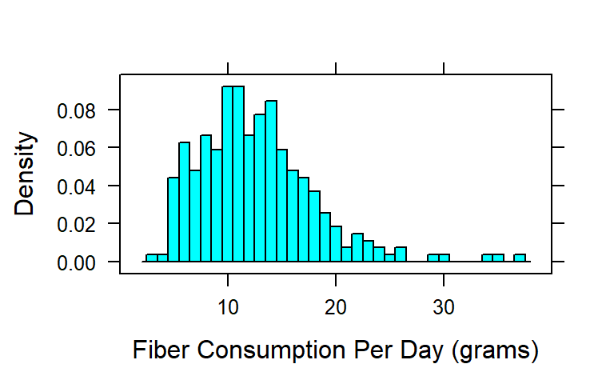

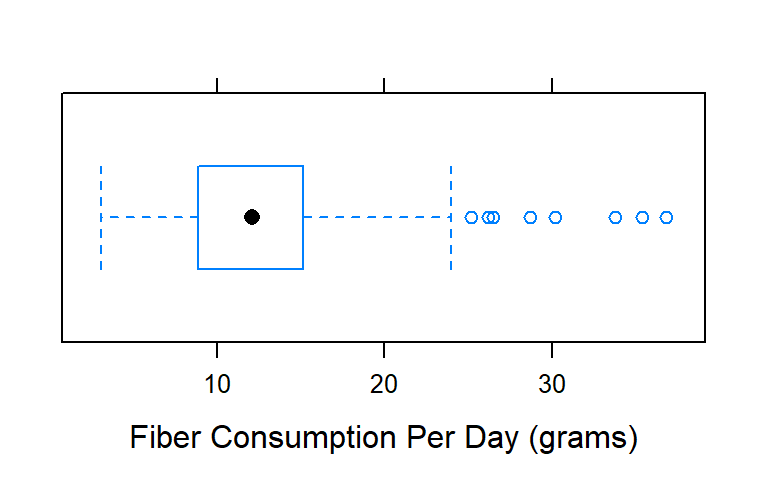

```r
histogram(~Fiber, width=1, data=nutri, xlab="Fiber Consumption Per Day (grams)")
bwplot(~Fiber,data=nutri, xlab="Fiber Consumption Per Day (grams)")
```

**Conditions:** The distribution of fiber consumption is a bit right-skewed with some outliers. Nonetheless, as the sample size $n=272$ is quite large, it’s okay to construct the $t$-confidence interval.

# Question 2 — Fiber (Cont’d)

```r
favstats(~Fiber, data=nutri)
```

```
##  min    Q1 median     Q3  max     mean       sd   n missing
##  3.1 8.875   12.1 15.125 36.8 12.68603 5.411927 272       0
```

# Question 3 — Beta Carotene & Smoking

Is there evidence of a difference in mean level of beta carotene in the blood (`BetaPlasma`) between smokers and non-smokers?

- What type of problem is it? One-sample? Two-sample? Paired? Is this about means or proportions?
- Is it appropriate to perform a two-sample t-test?

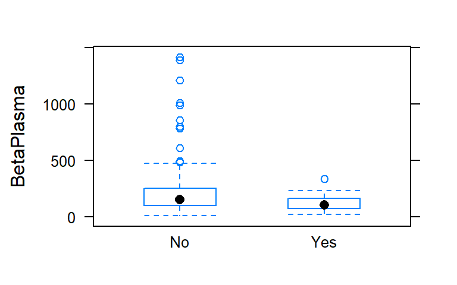

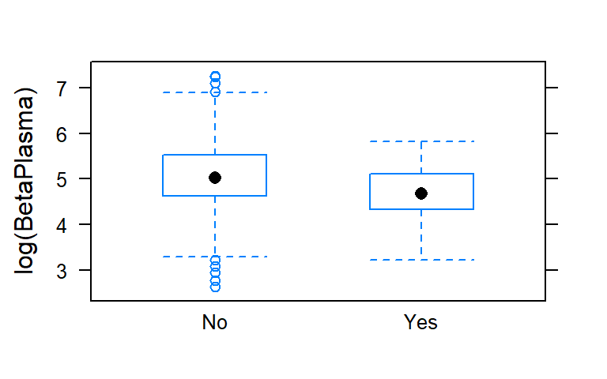

```r
bwplot(BetaPlasma ~ Smoke, data=nutri, horizontal=F)
bwplot(log(BetaPlasma) ~ Smoke, data=nutri, horizontal=F)
```

- In the original scale, both groups are right-skewed. The nonsmoking group has outliers 6 or 7 IQRs above Q3. It might not be safe to conduct the two-sample t-test, though the sample size are quite large (There are 36 smokers and 236 nonsmokers in the data.)
- In the logarithmic scale, both groups become symmetric and the outliers become less extreme. It’s safer to analyze `BetaPlasma` in the logarithmic scale.

# Question 3 — Beta Carotene & Smoking

```r
favstats(log(BetaPlasma) ~ Smoke, data=nutri)
```

```
##   Smoke      min       Q1   median       Q3      max     mean        sd
## 1    No 2.639057 4.624973 5.023859 5.534376 7.254885 5.056493 0.7397623
## 2   Yes 3.218876 4.337226 4.672654 5.105891 5.826000 4.623526 0.6034169
##     n missing
## 1 236       0
## 2  36       0
```

- H$_0$: Smokers and nonsmokers do not differ in their mean log(`BetaPlasma`) levels.
- H$_a$: Smokers and nonsmokers differ in their mean log(`BetaPlasma`) levels.
- two-sample t-statistic
  $$t = \frac{\bar{x}_{smoker}-\bar{x}_{nonsmoker}}{\sqrt{\frac{s^2_{smoker}}{n_{smoker}}+\frac{s^2_{nonsmoker}}{n_{nonsmoker}}}}
  =\frac{4.6235261-5.0564933}{\sqrt{\frac{0.6034169^2}{36}+
  \frac{0.7397623^2}{236}}}
  \approx\frac{-0.433}{0.112}
  \approx-3.883$$

# Question 3 — Beta Carotene & Smoking

- df $= \min(n_1-1, n_2-1)=\min(36-1,236-1)=35.$
- The two-sided P-value is about 2*pt(-3.883, df = 36 -1) $\approx$ 0.000437.
- Conclusion: At 5% (or 1%) significance level, the mean log(`BetaPlasma`) levels between smokers and nonsmokers differ significantly.

# Question 3 — Beta Carotene & Smoking

The test can be conducted using the `t.test()` command in R as follows

```r
t.test(log(BetaPlasma) ~ Smoke, data=nutri)
```

```
##
##  Welch Two Sample t-test
##
## data:  log(BetaPlasma) by Smoke
## t = 3.883, df = 52.478, p-value = 0.0002905
## alternative hypothesis: true difference in means is not equal to 0
## 95 percent confidence interval:
##  0.2092671 0.6566672
## sample estimates:
##  mean in group No mean in group Yes
##          5.056493          4.623526
```

The p-value reported is lower than our p-value because R use the more accurate software formula to calculate the df.

# Question 4 — Vitamin Use & Smoking

What percentage of smokers take vitamin regularly or occasionally? What is the corresponding percentage for nonsmokers? Is there a significant difference between the two percentages?

- What type of problem is it? One-sample? Two-sample? Paired? Is this about means or proportions?
- H$_0$: Smokers and nonsmokers do not differ in the percentages that take vitamin at least occasionally ($p_{smoker}=p_{nonsmoker}$)
- H$_a$: Smokers and nonsmokers differ in the percentages that take vitamin at least occasionally ($p_{smoker}\neq p_{nonsmoker}$)

# Question 4 — Vitamin Use & Smoking

```r
addmargins(tally(~ Smoke + VitaminUse, data=nutri))
```

```
##      VitaminUse
## Smoke  No Occasional Regular Sum
##   No   71         65     100 236
##   Yes  16         12       8  36
##   Sum  87         77     108 272
```

- The percentage of smokers that take vitamin regularly or occasionally is estimated to be $\hat{p}_{smoker}=X_1/n_1= (12+8)/ 36= 20/36\approx 0.5556=55.56\%$
- The percentage of nonsmokers that take vitamin regularly or occasionally is estimated to be $\hat{p}_{nonsmoker}=X_2/n_2= (65+100)/ 236= 165/236\approx 0.6992=69.92\%$
- Under H$_0$: $p_{smoker}=p_{nonsmoker}$, the pool estimate for the common proportion is $\hat{p}_{pooled}=(X_1+X_2)/(n_1+n_2)=(20+165)/(36+236) \approx0.6801$

# Question 4 — Vitamin Use & Smoking

- $$\begin{align*}
  z\text{-statistic} &= \frac{\hat{p}_{smoker}-\hat{p}_{nonsmoker}}{\sqrt{\hat{p}_{pooled}(1-\hat{p}_{pooled})(\frac{1}{n_{smoker}}+\frac{1}{n_{nonsmoker}})}}\\
  &\approx\frac{0.5556-0.6992}{\sqrt{0.6801(1-0.6801)(\frac{1}{36}+\frac{1}{236})}}
  \approx\frac{-0.1436}{0.0835}
  \approx-1.7206
  \end{align*}$$
- The two-sided p-value is `2*pnorm(-1.7206)` $\approx$ 0.0853234
- Conclusion: As the P-value exceeds 5%, we conclude that there is no significant difference in the percentages that take vitamin at least occasionally between Smokers and nonsmokers, probably because of the small sample size of smokers.
- Conditions:
  $$\begin{align*}
  n_{smokers}\hat{p}_{pooled}&=36\times0.68>10,\;
  n_{smokers}(1-\hat{p}_{pooled})=36(1-0.68)>10,\\
  n_{nonsmokers}\hat{p}_{pooled}&=236\times0.68>10,
  n_{nonsmokers}(1-\hat{p}_{pooled})=236(1-0.68)>10.
  \end{align*}$$